# Treatment Pathways

Joe Sartini

2026-09-01

# Set-up

First, all necessary libraries are imported, the data is read in, and all necessary variables are produced.

```r
# First, the libraries
# If you want to replicate my environment exactly, use renv::restore()
library(tidyverse)
library(mediation)
library(lavaan)
library(knitr)
select = dplyr::select

# Next, reading the data
GLAB = c("Mindset", "Education", "No-intervention")
df = read.csv("../deidentified_data.csv") %>%
  mutate(group = recode_values(t2_Group.ID, from = c(1, 2, 3),
                               to = GLAB), # Group names
         group = factor(group, levels = GLAB[c(3,2,1)]),
         female = case_when(t1_sex == 1 ~ 1,
                            t1_sex == 0 ~ 0,
                            TRUE ~ NA), # Recode sex
         t3_OAcomp = t3_IMI_man + t3_IMI_opp - t3_IMI_cat,
         t2_OAcomp = t2_IMI_man + t2_IMI_opp - t2_IMI_cat,
         t1_OAcomp = t1_IMI_man + t1_IMI_opp - t1_IMI_cat,
         bilateral = case_when(t1_uni.bi == 5 ~ 1,
                               t1_uni.bi == 4 ~ 0,
                               TRUE ~ NA),
         minority = case_when(!(t1_race %in% c("6", "")) ~ 1,
                              TRUE ~ 0),
         employed = case_when(grepl("[1-2]", t1_employment) ~ 1,
                              TRUE ~ 0),
         depression = case_when(grepl("10", t1_med.cond) ~ 1,
                                TRUE ~ 0),
         n_comorbid = lengths(strsplit(t1_med.cond, ",")))
```

# Generate Table 1

```r
library(ggtext)
library(table1)
library(kableExtra)
for_t1 = df %>%
  mutate(female = case_when(female == 1 ~ T,
                            T ~ F),
         employed = case_when(employed == 1 ~ T,
                              T ~ F),
         depression = case_when(depression == 1 ~ T,
                                T ~ F),
         minority = case_when(minority == 1 ~ T,
                              T ~ F))

# Labels
label(for_t1$t1_age) = "Age"
label(for_t1$t1_height) = "Height"
label(for_t1$t1_weight) = "Weight"
label(for_t1$female) = "Female (%)"
label(for_t1$minority) = "Minority (%)"
label(for_t1$employed) = "Employed (%)"
label(for_t1$depression) = "Depression (%)"
label(for_t1$n_comorbid) = "# Comorbidities"

# Units
units(for_t1$t1_age) = "years"
units(for_t1$t1_height) = "in"
units(for_t1$t1_weight) = "lb"

# Render
rndr <- function(x, ...) {
    y <- render.default(x, ...)
    if (is.logical(x)) y[2] else y
}

x = table1(~  t1_age + t1_height + t1_weight + female + minority + employed + depression + n_comorbid |group,
       data = for_t1, render = rndr)

table_out = t1kable(x, format = "latex")
save_kable(table_out, file = "table1.tex")
```

# OA Mindset Mediation of Treatment Effects on 5 Outcomes

## Mediation

We perform separate causal mediation analyses to assess OA mindset at time point 2 as a potential mediator of the treatment effect on 5 outcomes at time point 3, adjusted for baseline values. The outcomes include perceived need for surgery, self-imposed physical limitation (conditional on use of the strategy at time point 1), fear of movement, pain self-efficacy, and other symptom self-efficacy.

We assess mediation of the treatment effect contrasting both the no intervention and education arms with the mindset treatment arm. Generalized linear models are used to model the binary removal of self-imposed physical limitation outcome. Uncertainty is assessed using bootstrap inference for all outcomes except self-imposed physical limitation, for which robust standard errors are calculated.

```r
set.seed(123456)
outcomes = c("surgery", "management_11", "TSK_avg", "ASE_pain_avg", "ASE_function_avg")

out_names = c("Perceived need for surgery",
              "Imposing physical limitations",
              "Fear of movement",
              "Pain self-efficacy",
              "Other symptom self-efficacy")

build_ind = function(outcome){
  if(outcome == "management_11"){
    mod_spec = paste0(
      '

  # Mediator Model at time 2
  t2_OAcomp ~ a1 * No + a2 * Edu + t1_OAcomp

  # Outcome models
  t3_',
  outcome,
  '~ c1 * No + c2 * Edu + d * t2_OAcomp

  # Indirect effects
  med_OAcomp_No := a1 * d
  med_OAcomp_Edu := a2 * d

  # Total effects
  total_both_No := c1 + (a1 * d)
  total_both_Edu := c2 + (a2 * d)
  '
    )
  }
  else{
    mod_spec = paste0(
      '

  # Mediator Model at time 2
  t2_OAcomp ~ a1 * No + a2 * Edu + t1_OAcomp

  # Outcome models
  t3_',
  outcome,
  '~ c1 * No + c2 * Edu + d * t2_OAcomp + t1_',
  outcome,
  '

  # Indirect effects
  med_OAcomp_No := a1 * d
  med_OAcomp_Edu := a2 * d

  # Total effects
  total_both_No := c1 + (a1 * d)
  total_both_Edu := c2 + (a2 * d)
  '
    )
  }

  return(mod_spec)
}

ind_df = data.frame()
for(idx in 1:length(outcomes)){
  # Variable and corresponding SEM model
  varname = outcomes[idx]
  model_spec = build_ind(varname)

  # Create treatment group dummy variables
  fit_df = df %>%
    mutate(
      Edu = case_when(group == "Education" ~ 1, TRUE ~ 0),
      No = case_when(group == "No-intervention" ~ 1, TRUE ~ 0)
    )

  # Separate if binary outcome
  if(varname == "management_11"){
    fit_df = fit_df %>%
      filter(t1_management_11 == 1) %>%
      mutate(t3_management_11 = ordered(t3_management_11, levels = c(0, 1)))

    fit = sem(
      model = model_spec,
      data = fit_df,
      se = "robust"
    )
  }
  else{
    fit = sem(
      model = model_spec,
      data = fit_df,
      parallel = "multicore",
      ncpus = 8,
      se = "boot",
      bootstrap = 50000
    )
  }

  outcome_df = parameterEstimates(fit, boot.ci.type = "bca.simple") %>%
    filter(label %in% c("med_OAcomp_No", "med_OAcomp_Edu",
                        "total_both_No", "total_both_Edu")) %>%
    select(label, est, pvalue, ci.lower, ci.upper) %>%
    separate_wider_delim(label, delim = "_", names = c("Type", "Mediator", "Comparison")) %>%
    mutate(Comparison = case_when(Comparison == "No" ~ "No-intervention",
                                  TRUE ~ "Education"),
           Effect = case_when(Mediator == "OAcomp" ~ "OA Mindset",
                              TRUE ~ "Total"),
           Outcome = out_names[idx],
           est = -1 * est, CI_LB = -1 * ci.upper, CI_UB = -1 * ci.lower,
           `Sample Size` = nobs(fit)) %>%
    select(Comparison, Outcome, Effect, est, CI_LB, CI_UB, pvalue, `Sample Size`)

  ind_df = rbind(ind_df, outcome_df)
}

ind_df %>%
  arrange(Effect, Comparison, Outcome) %>%
  data.frame()
```

| Comparison | Outcome | Effect | est | CI_LB | CI_UB | pvalue | Sample.Size |
| --- | --- | --- | --- | --- | --- | --- | --- |
| Education | Fear of movement | OA Mindset | -0.1469824 | -0.20940232 | -0.09763917 | 2.387198e-07 | 408 |
| Education | Imposing physical limitations | OA Mindset | -0.1909769 | -0.31979761 | -0.06215626 | 3.664900e-03 | 279 |
| Education | Other symptom self-efficacy | OA Mindset | 0.5414346 | 0.35041419 | 0.78242266 | 7.675633e-07 | 408 |
| Education | Pain self-efficacy | OA Mindset | 0.5689667 | 0.38821006 | 0.79327442 | 3.292655e-08 | 408 |
| Education | Perceived need for surgery | OA Mindset | -0.1036993 | -0.19105944 | -0.03696266 | 7.778144e-03 | 408 |
| No-intervention | Fear of movement | OA Mindset | -0.2642999 | -0.34619050 | -0.19651142 | 4.345191e-12 | 408 |
| No-intervention | Imposing physical limitations | OA Mindset | -0.3064796 | -0.49846744 | -0.11449171 | 1.755301e-03 | 279 |
| No-intervention | Other symptom self-efficacy | OA Mindset | 0.9735936 | 0.71619837 | 1.27540005 | 8.567147e-12 | 408 |
| No-intervention | Pain self-efficacy | OA Mindset | 1.0231010 | 0.78794997 | 1.30025468 | 3.330669e-15 | 408 |
| No-intervention | Perceived need for surgery | OA Mindset | -0.1864694 | -0.32513386 | -0.06476133 | 4.656317e-03 | 408 |

[output cut: 10 more lines]

We see that mindset mediates the treatment effects for both contrasts and all outcomes quite strongly.

## Multiple Testing Adjustment

We can perform a simple multiple testing adjustment of the 10 raw p-values so far estimated, grouped together as part of examining the potential exercise mindset mediation of the treatment effect(s) the chosen outcomes.

```r
# Restrict just to the mindset indirect effects
view_df = ind_df %>%
  filter(Effect == "OA Mindset") %>%
  select(Comparison, Outcome, pvalue)

# Adjust the p-values using Benjamini-Hochberg and Bonferroni
view_df$BH = p.adjust(view_df$pvalue, method = "BH")
view_df$Bonferroni = p.adjust(view_df$pvalue, method = "bonferroni")

# Visualize
view_df %>%
  arrange(BH) %>%
  mutate(Significant = case_when(BH < 0.05 ~ "Yes",
                                 TRUE ~ "No")) %>%
  data.frame()
```

| Comparison | Outcome | pvalue | BH | Bonferroni | Significant |
| --- | --- | --- | --- | --- | --- |
| No-intervention | Pain self-efficacy | 3.330669e-15 | 3.330669e-14 | 3.330669e-14 | Yes |
| No-intervention | Fear of movement | 4.345191e-12 | 2.172595e-11 | 4.345191e-11 | Yes |
| No-intervention | Other symptom self-efficacy | 8.567147e-12 | 2.855716e-11 | 8.567147e-11 | Yes |
| Education | Pain self-efficacy | 3.292655e-08 | 8.231637e-08 | 3.292655e-07 | Yes |
| Education | Fear of movement | 2.387198e-07 | 4.774395e-07 | 2.387198e-06 | Yes |
| Education | Other symptom self-efficacy | 7.675633e-07 | 1.279272e-06 | 7.675633e-06 | Yes |
| No-intervention | Imposing physical limitations | 1.755301e-03 | 2.507573e-03 | 1.755301e-02 | Yes |
| Education | Imposing physical limitations | 3.664900e-03 | 4.581126e-03 | 3.664900e-02 | Yes |
| No-intervention | Perceived need for surgery | 4.656317e-03 | 5.173685e-03 | 4.656317e-02 | Yes |
| Education | Perceived need for surgery | 7.778144e-03 | 7.778144e-03 | 7.778144e-02 | Yes |

## Summary Table

We collate the above results into a final table containing all relevant information.

```r
ind_df %>%
  filter(Effect == "OA Mindset") %>%
  select(-c(Effect, pvalue)) %>%
  inner_join(view_df, by = c("Comparison", "Outcome")) %>%
  arrange(Outcome, Comparison) %>%
  rename(Estimate = est, `CI Lower` = CI_LB,
         `CI Upper` = CI_UB, `P Value` = pvalue,
         `Benjamini Hochberg` = BH) %>%
  data.frame()
```

[output not shown]

## Visualization

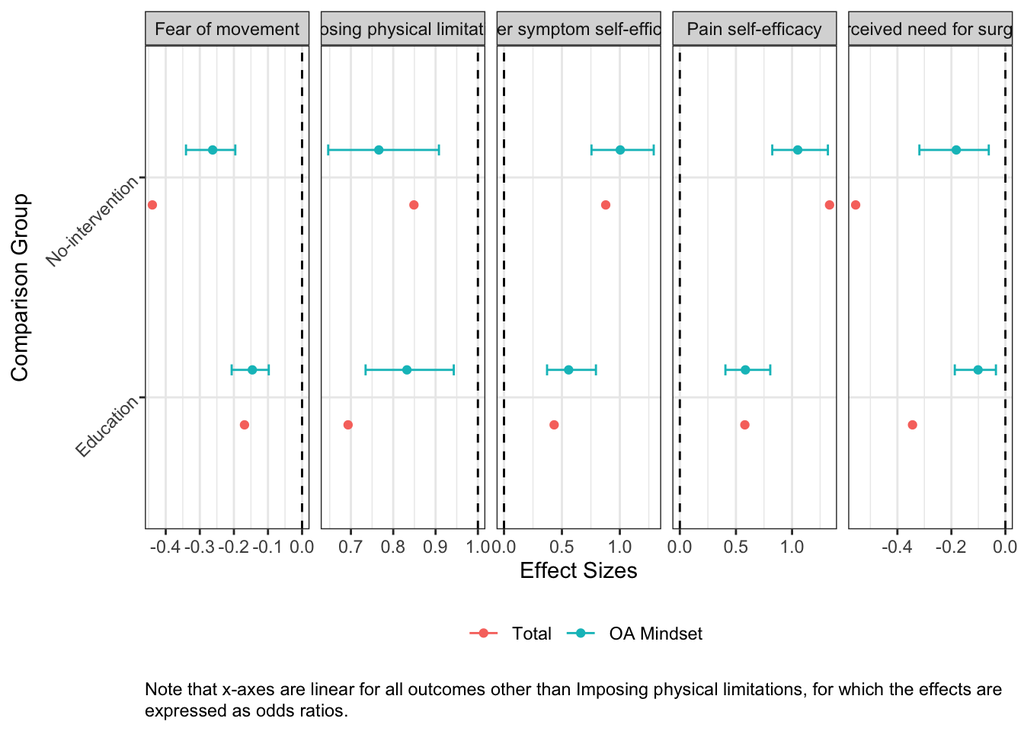

```r
est_df = ind_df %>%
  select(-c(pvalue)) %>%
  mutate(Effect = factor(Effect, levels = c("Total", "OA Mindset"))) %>%
  rename(Est = est, Measure = Effect) %>%
  mutate(CI_UB = case_when(Measure == "Total" ~ NA,
                           TRUE ~ CI_UB),
         CI_LB = case_when(Measure == "Total" ~ NA,
                           TRUE ~ CI_LB))

pd = position_dodge(width = 0.5, orientation = "y")
ref_lines = data.frame(Outcome = out_names,
                       xint = c(0,1,0,0,0))
est_df %>%
  mutate(Est = case_when(Outcome == "Imposing physical limitations" ~ exp(Est),
                         TRUE ~ Est),
         CI_UB = case_when(Outcome == "Imposing physical limitations" ~ exp(CI_UB),
                         TRUE ~ CI_UB),
         CI_LB = case_when(Outcome == "Imposing physical limitations" ~ exp(CI_LB),
                         TRUE ~ CI_LB)) %>%
  ggplot(aes(x = Est, y = Comparison, color = Measure, group = Measure)) +
  geom_point(position = pd) +
  geom_errorbar(aes(xmin = CI_LB, xmax = CI_UB), width = 0.1,
                position = pd) +
  geom_vline(data = ref_lines, aes(xintercept = xint), linetype = "dashed") +
  theme_bw() +
  theme(axis.text.y = element_text(angle = 45, vjust = 0.5, hjust = 1),
        plot.caption = element_textbox_simple(margin = margin(t = 10)),
        legend.position = "bottom") +
  facet_wrap(.~Outcome, scales = "free_x", nrow = 1) +
  labs(x = "Effect Sizes", y = "Comparison Group", caption = "Note that x-axes are linear for all outcomes other than Imposing physical limitations, for which the effects are expressed as odds ratios.",
       color = "")
```

# OA Mindset Mediation of Treatment Effects on 4 Standardized Outcomes (Sensitivity)

## Mediation

We perform separate causal mediation analyses to assess OA mindset at time point 2 as a potential mediator of the treatment effect on the 4 continuous outcomes at time point 3 adjusted for baseline values, all appropriately z-scored. The outcomes include perceived need for surgery, fear of movement, pain self-efficacy, and other symptom self-efficacy. We assess mediation of the treatment effect using an analogous approach to the previous raw analyses.

```r
set.seed(123456)
outcomes = c("surgery", "TSK_avg", "ASE_pain_avg", "ASE_function_avg")

out_names = c("Perceived need for surgery",
              "Fear of movement",
              "Pain self-efficacy",
              "Other symptom self-efficacy")

# Standardize outcomes
sd_surgery = sd(fit_df$t1_surgery)
sd_fmovt = sd(fit_df$t1_TSK_avg)
sd_pseff = sd(fit_df$t1_ASE_pain_avg)
sd_oseff = sd(fit_df$t1_ASE_function_avg)

std_df = df %>%
  mutate(t3_surgery = t3_surgery/sd_surgery,
         t1_surgery = t1_surgery/sd_surgery,
         t3_TSK_avg = t3_TSK_avg/sd_fmovt,
         t1_TSK_avg = t1_TSK_avg/sd_fmovt,
         t3_ASE_pain_avg = t3_ASE_pain_avg/sd_pseff,
         t1_ASE_pain_avg = t1_ASE_pain_avg/sd_pseff,
         t3_ASE_function_avg = t3_ASE_function_avg/sd_oseff,
         t1_ASE_function_avg = t1_ASE_function_avg/sd_oseff)

build_ind = function(outcome){

  mod_spec = paste0(
    '

  # Mediator Model at time 2
  t2_OAcomp ~ a1 * No + a2 * Edu + t1_OAcomp

  # Outcome models
  t3_',
  outcome,
  '~ c1 * No + c2 * Edu + d * t2_OAcomp + t1_',
  outcome,
  '

  # Indirect effects
  med_OAcomp_No := a1 * d
  med_OAcomp_Edu := a2 * d

  # Total effects
  total_both_No := c1 + (a1 * d)
  total_both_Edu := c2 + (a2 * d)
  '
  )

  return(mod_spec)
}

ind_df = data.frame()
for(idx in 1:length(outcomes)){
  # Variable and corresponding SEM model
  varname = outcomes[idx]
  model_spec = build_ind(varname)

  # Create treatment group dummy variables
  std_df = std_df %>%
    mutate(
      Edu = case_when(group == "Education" ~ 1, TRUE ~ 0),
      No = case_when(group == "No-intervention" ~ 1, TRUE ~ 0)
    )

  # Separate if binary outcome
  fit = sem(
    model = model_spec,
    data = std_df,
    parallel = "multicore",
    ncpus = 8,
    se = "boot",
    bootstrap = 50000
  )

  outcome_df = parameterEstimates(fit, boot.ci.type = "bca.simple") %>%
    filter(label %in% c("med_OAcomp_No", "med_OAcomp_Edu",
                        "total_both_No", "total_both_Edu")) %>%
    select(label, est, pvalue, ci.lower, ci.upper) %>%
    separate_wider_delim(label, delim = "_", names = c("Type", "Mediator", "Comparison")) %>%
    mutate(Comparison = case_when(Comparison == "No" ~ "No-intervention",
                                  TRUE ~ "Education"),
           Effect = case_when(Mediator == "OAcomp" ~ "OA Mindset",
                              TRUE ~ "Total"),
           Outcome = out_names[idx],
           est = -1 * est, CI_LB = -1 * ci.upper, CI_UB = -1 * ci.lower,
           `Sample Size` = nobs(fit)) %>%
    select(Comparison, Outcome, Effect, est, CI_LB, CI_UB, pvalue, `Sample Size`)

  ind_df = rbind(ind_df, outcome_df)
}

ind_df %>%
  arrange(Effect, Comparison, Outcome) %>%
  data.frame()
```

| Comparison | Outcome | Effect | est | CI_LB | CI_UB | pvalue | Sample.Size |
| --- | --- | --- | --- | --- | --- | --- | --- |
| Education | Fear of movement | OA Mindset | -0.22136522 | -0.31537382 | -0.14705108 | 2.387190e-07 | 408 |
| Education | Other symptom self-efficacy | OA Mindset | 0.25900033 | 0.16762392 | 0.37427925 | 7.675588e-07 | 408 |
| Education | Pain self-efficacy | OA Mindset | 0.27532454 | 0.18785590 | 0.38386765 | 3.292629e-08 | 408 |
| Education | Perceived need for surgery | OA Mindset | -0.09279129 | -0.17096209 | -0.03307462 | 7.778144e-03 | 408 |
| No-intervention | Fear of movement | OA Mindset | -0.39805316 | -0.52138583 | -0.29595930 | 4.345191e-12 | 408 |
| No-intervention | Other symptom self-efficacy | OA Mindset | 0.46572763 | 0.34260023 | 0.61009961 | 8.567147e-12 | 408 |
| No-intervention | Pain self-efficacy | OA Mindset | 0.49508140 | 0.38129120 | 0.62919704 | 3.330669e-15 | 408 |
| No-intervention | Perceived need for surgery | OA Mindset | -0.16685488 | -0.29093330 | -0.05794901 | 4.656316e-03 | 408 |
| Education | Fear of movement | Total | -0.24691155 | -0.41623988 | -0.07631604 | 4.466232e-03 | 408 |
| Education | Other symptom self-efficacy | Total | 0.20607675 | 0.04062099 | 0.37430396 | 1.547818e-02 | 408 |

[output cut: 6 more lines]

## Summary Table

We collate the results from fitting the above models into a final table containing all relevant information.

```r
# Restrict just to the mindset indirect effects
view_df = ind_df %>%
  filter(Effect == "OA Mindset") %>%
  select(Comparison, Outcome, pvalue)

# Adjust the p-values using Benjamini-Hochberg and Bonferroni
view_df$BH = p.adjust(view_df$pvalue, method = "BH")
view_df$Bonferroni = p.adjust(view_df$pvalue, method = "bonferroni")

ind_df %>%
  filter(Effect == "OA Mindset") %>%
  select(-c(Effect, pvalue)) %>%
  inner_join(view_df, by = c("Comparison", "Outcome")) %>%
  arrange(Outcome, Comparison) %>%
  rename(Estimate = est, `CI Lower` = CI_LB,
         `CI Upper` = CI_UB, `P Value` = pvalue,
         `Benjamini Hochberg` = BH) %>%
  data.frame()
```

| Comparison | Outcome | Estimate | CI.Lower | CI.Upper | Sample.Size | P.Value | Benjamini.Hochberg | Bonferroni |
| --- | --- | --- | --- | --- | --- | --- | --- | --- |
| Education | Fear of movement | -0.22136522 | -0.3153738 | -0.14705108 | 408 | 2.387190e-07 | 3.819504e-07 | 1.909752e-06 |
| No-intervention | Fear of movement | -0.39805316 | -0.5213858 | -0.29595930 | 408 | 4.345191e-12 | 1.738076e-11 | 3.476153e-11 |
| Education | Other symptom self-efficacy | 0.25900033 | 0.1676239 | 0.37427925 | 408 | 7.675588e-07 | 1.023412e-06 | 6.140470e-06 |
| No-intervention | Other symptom self-efficacy | 0.46572763 | 0.3426002 | 0.61009961 | 408 | 8.567147e-12 | 2.284573e-11 | 6.853718e-11 |
| Education | Pain self-efficacy | 0.27532454 | 0.1878559 | 0.38386765 | 408 | 3.292629e-08 | 6.585259e-08 | 2.634104e-07 |
| No-intervention | Pain self-efficacy | 0.49508140 | 0.3812912 | 0.62919704 | 408 | 3.330669e-15 | 2.664535e-14 | 2.664535e-14 |
| Education | Perceived need for surgery | -0.09279129 | -0.1709621 | -0.03307462 | 408 | 7.778144e-03 | 7.778144e-03 | 6.222515e-02 |
| No-intervention | Perceived need for surgery | -0.16685488 | -0.2909333 | -0.05794901 | 408 | 4.656316e-03 | 5.321504e-03 | 3.725053e-02 |

We see that mindset indirect effects are of similar magnitude for the two forms of self-efficacy across both comparison groups. Fear of movement indirect effects are actually quite similar in magnitude to the self-efficacy effects, but in the reverse direction. The weakest effect, though still significant, appears to be the indirect effect on perceived need for surgery.

# OA Mindset and OA Knowledge Joint Mediation

We can re-run these same analyses including OA knowledge as a co-mediator to assess whether OA mindset mediates the treatment effect given concurrent effects on OA knowledge.

```r
set.seed(123456)
outcomes = c("surgery", "management_11", "TSK_avg", "ASE_pain_avg", "ASE_function_avg")

out_names = c("Perceived need for surgery",
              "Imposing physical limitations",
              "Fear of movement",
              "Pain self-efficacy",
              "Other symptom self-efficacy")

build_joint = function(outcome){
  if(outcome == "management_11"){
    mod_spec = paste0(
      '
  # Autoregressive models
  t3_OAcomp ~ t2_OAcomp
  t3_KOAS ~ t2_KOAS

  # Mediation Models
  t2_OAcomp ~ a1 * No + a2 * Edu + t1_OAcomp
  t2_KOAS ~ b1 * No + b2 * Edu + t1_KOAS

  # Outcome models
  t3_',
  outcome,
  '~ e1 * No + e2 * Edu + f * t2_OAcomp + g * t2_KOAS

  # Indirect effects
  med_OAcomp_No := a1 * f
  med_OAcomp_Edu := a2 * f

  med_KOAS_No := b1 * g
  med_KOAS_Edu := b2 * g

  # Total effects
  total_both_No := e1 + a1 * f + b1 * g
  total_both_Edu := e2 + a2 * f + b2 * g

  # Allow residual correlation of mediators
  t2_OAcomp ~~ t2_KOAS
  t3_OAcomp ~~ t3_KOAS
  '
    )
  }
  else{
    mod_spec = paste0(
      '
  # Autoregressive models
  t3_OAcomp ~ t2_OAcomp
  t3_KOAS ~ t2_KOAS

  # Mediation Models
  t2_OAcomp ~ a1 * No + a2 * Edu + t1_OAcomp
  t2_KOAS ~ b1 * No + b2 * Edu + t1_KOAS

  # Outcome models
  t3_',
  outcome,
  '~ e1 * No + e2 * Edu + f * t2_OAcomp + g * t2_KOAS + t1_',
  outcome,
  '

  # Indirect effects
  med_OAcomp_No := a1 * f
  med_OAcomp_Edu := a2 * f

  med_KOAS_No := b1 * g
  med_KOAS_Edu := b2 * g

  # Total effects
  total_both_No := e1 + a1 * f + b1 * g
  total_both_Edu := e2 + a2 * f + b2 * g

  # Allow residual correlation of mediators
  t2_OAcomp ~~ t2_KOAS
  t3_OAcomp ~~ t3_KOAS
  '
    )
  }


  return(mod_spec)
}

joint_df = data.frame()
for(idx in 1:length(outcomes)){
  # Variable and corresponding SEM model
  varname = outcomes[idx]
  model_spec = build_joint(varname)

  # Create treatment group dummy variables
  fit_df = df %>%
    mutate(
      Edu = case_when(group == "Education" ~ 1, TRUE ~ 0),
      No = case_when(group == "No-intervention" ~ 1, TRUE ~ 0)
    )

  # Separate if binary outcome
  if(varname == "management_11"){
    fit_df = fit_df %>%
      filter(t1_management_11 == 1) %>%
      mutate(t3_management_11 = ordered(t3_management_11, levels = c(0, 1)))

    fit = sem(
      model = model_spec,
      data = fit_df,
      se = "robust"
    )
  }
  else{
    fit = sem(
      model = model_spec,
      data = fit_df,
      parallel = "multicore",
      ncpus = 8,
      se = "boot",
      bootstrap = 50000
    )
  }


  outcome_df = parameterEstimates(fit, boot.ci.type = "bca.simple") %>%
    filter(label %in% c("med_OAcomp_No", "med_OAcomp_Edu",
                        "med_KOAS_No", "med_KOAS_Edu",
                        "total_both_No", "total_both_Edu")) %>%
    select(label, est, pvalue, ci.lower, ci.upper) %>%
    separate_wider_delim(label, delim = "_", names = c("Type", "Mediator", "Comparison")) %>%
    mutate(Comparison = case_when(Comparison == "No" ~ "No-intervention",
                                  TRUE ~ "Education"),
           Effect = case_when(Mediator == "OAcomp" ~ "OA Mindset",
                              Mediator == "KOAS" ~ "OA Knowledge",
                              TRUE ~ "Total"),
           Outcome = out_names[idx],
           est = -1 * est, CI_LB = -1 * ci.upper, CI_UB = -1 * ci.lower,
           `Sample Size` = nobs(fit)) %>%
    select(Comparison, Outcome, Effect, est, CI_LB, CI_UB, pvalue,
          `Sample Size`)

  joint_df = rbind(joint_df, outcome_df)
}

joint_df %>%
  arrange(Effect, Comparison, Outcome) %>%
  data.frame()
```

| Comparison | Outcome | Effect | est | CI_LB | CI_UB | pvalue | Sample.Size |
| --- | --- | --- | --- | --- | --- | --- | --- |
| Education | Fear of movement | OA Knowledge | -0.08162072 | -0.14385160 | -0.02512342 | 6.937173e-03 | 408 |
| Education | Imposing physical limitations | OA Knowledge | -0.12868355 | -0.34741158 | 0.09004448 | 2.488697e-01 | 279 |
| Education | Other symptom self-efficacy | OA Knowledge | 0.10960669 | -0.05590043 | 0.27856768 | 1.961594e-01 | 408 |
| Education | Pain self-efficacy | OA Knowledge | 0.26256496 | 0.11329022 | 0.42313753 | 9.241789e-04 | 408 |
| Education | Perceived need for surgery | OA Knowledge | -0.15716344 | -0.28898825 | -0.03365747 | 1.554437e-02 | 408 |
| No-intervention | Fear of movement | OA Knowledge | -0.10895491 | -0.18776348 | -0.03314159 | 5.727403e-03 | 408 |
| No-intervention | Imposing physical limitations | OA Knowledge | -0.17865567 | -0.47962951 | 0.12231818 | 2.446596e-01 | 279 |
| No-intervention | Other symptom self-efficacy | OA Knowledge | 0.14631289 | -0.07543075 | 0.36851956 | 1.955320e-01 | 408 |
| No-intervention | Pain self-efficacy | OA Knowledge | 0.35049571 | 0.14885707 | 0.55858069 | 8.235654e-04 | 408 |
| No-intervention | Perceived need for surgery | OA Knowledge | -0.20979631 | -0.38008112 | -0.04359640 | 1.397376e-02 | 408 |

[output cut: 20 more lines]

Even in the presence of mediation from changes in OA knowledge, there is a statistically significant indirect effect indicating mediation of OA mindset on all outcomes save imposing physical limitations and perceived need for surgery.

## Multiple Testing Adjustment

We can perform a simple multiple testing adjustment of the 10 raw p-values so far estimated for each potential mediator, grouped together as part of examining the potential exercise mindset/OA knowledge mediation of the treatment effect(s) the chosen outcomes.

```r
# Join outputs of the previous two analyses
view_df_OAcomp = joint_df %>%
  filter(Effect == "OA Mindset") %>%
  select(Comparison, Outcome, Effect, pvalue)

view_df_OAknow = joint_df %>%
  filter(Effect == "OA Knowledge") %>%
  select(Comparison, Outcome, Effect, pvalue)

# Adjust the p-values using Benjamini-Hochberg and Bonferroni
view_df_OAcomp$BH = p.adjust(view_df_OAcomp$pvalue, method = "BH")
view_df_OAcomp$Bonferroni = p.adjust(view_df_OAcomp$pvalue, method = "bonferroni")

view_df_OAknow$BH = p.adjust(view_df_OAknow$pvalue, method = "BH")
view_df_OAknow$Bonferroni = p.adjust(view_df_OAknow$pvalue, method = "bonferroni")

# Visualize
view_df = rbind(view_df_OAknow, view_df_OAcomp)
view_df %>%
  arrange(Effect, Comparison, Outcome) %>%
  data.frame()
```

| Comparison | Outcome | Effect | pvalue | BH | Bonferroni |
| --- | --- | --- | --- | --- | --- |
| Education | Fear of movement | OA Knowledge | 6.937173e-03 | 1.734293e-02 | 6.937173e-02 |
| Education | Imposing physical limitations | OA Knowledge | 2.488697e-01 | 2.488697e-01 | 1.000000e+00 |
| Education | Other symptom self-efficacy | OA Knowledge | 1.961594e-01 | 2.451993e-01 | 1.000000e+00 |
| Education | Pain self-efficacy | OA Knowledge | 9.241789e-04 | 4.620894e-03 | 9.241789e-03 |
| Education | Perceived need for surgery | OA Knowledge | 1.554437e-02 | 2.590729e-02 | 1.554437e-01 |
| No-intervention | Fear of movement | OA Knowledge | 5.727403e-03 | 1.734293e-02 | 5.727403e-02 |
| No-intervention | Imposing physical limitations | OA Knowledge | 2.446596e-01 | 2.488697e-01 | 1.000000e+00 |
| No-intervention | Other symptom self-efficacy | OA Knowledge | 1.955320e-01 | 2.451993e-01 | 1.000000e+00 |
| No-intervention | Pain self-efficacy | OA Knowledge | 8.235654e-04 | 4.620894e-03 | 8.235654e-03 |
| No-intervention | Perceived need for surgery | OA Knowledge | 1.397376e-02 | 2.590729e-02 | 1.397376e-01 |

[output cut: 10 more lines]

After Benjamini-Hochberg and Bonferroni correction, none of the statistical significance results for mediation of the treatment effect due to OA mindset, even considering co-mediation by OA knowledge, qualitatively change.

## Summary Table

As in the single mediation analyses, we can collate the above results into a final table containing all relevant information.

```r
joint_df %>%
  select(-c(pvalue)) %>%
  inner_join(view_df, by = c("Comparison", "Outcome", "Effect")) %>%
  arrange(Effect, Outcome, Comparison) %>%
  rename(Estimate = est, `CI Lower` = CI_LB,
         `CI Upper` = CI_UB, `P Value` = pvalue,
         `Benjamini Hochberg` = BH) %>%
  data.frame()
```

| Comparison | Outcome | Effect | Estimate | CI.Lower | CI.Upper | Sample.Size | P.Value | Benjamini.Hochberg | Bonferroni |
| --- | --- | --- | --- | --- | --- | --- | --- | --- | --- |
| Education | Fear of movement | OA Knowledge | -0.08162072 | -0.14385160 | -0.02512342 | 408 | 6.937173e-03 | 1.734293e-02 | 6.937173e-02 |
| No-intervention | Fear of movement | OA Knowledge | -0.10895491 | -0.18776348 | -0.03314159 | 408 | 5.727403e-03 | 1.734293e-02 | 5.727403e-02 |
| Education | Imposing physical limitations | OA Knowledge | -0.12868355 | -0.34741158 | 0.09004448 | 279 | 2.488697e-01 | 2.488697e-01 | 1.000000e+00 |
| No-intervention | Imposing physical limitations | OA Knowledge | -0.17865567 | -0.47962951 | 0.12231818 | 279 | 2.446596e-01 | 2.488697e-01 | 1.000000e+00 |
| Education | Other symptom self-efficacy | OA Knowledge | 0.10960669 | -0.05590043 | 0.27856768 | 408 | 1.961594e-01 | 2.451993e-01 | 1.000000e+00 |
| No-intervention | Other symptom self-efficacy | OA Knowledge | 0.14631289 | -0.07543075 | 0.36851956 | 408 | 1.955320e-01 | 2.451993e-01 | 1.000000e+00 |
| Education | Pain self-efficacy | OA Knowledge | 0.26256496 | 0.11329022 | 0.42313753 | 408 | 9.241789e-04 | 4.620894e-03 | 9.241789e-03 |
| No-intervention | Pain self-efficacy | OA Knowledge | 0.35049571 | 0.14885707 | 0.55858069 | 408 | 8.235654e-04 | 4.620894e-03 | 8.235654e-03 |
| Education | Perceived need for surgery | OA Knowledge | -0.15716344 | -0.28898825 | -0.03365747 | 408 | 1.554437e-02 | 2.590729e-02 | 1.554437e-01 |
| No-intervention | Perceived need for surgery | OA Knowledge | -0.20979631 | -0.38008112 | -0.04359640 | 408 | 1.397376e-02 | 2.590729e-02 | 1.397376e-01 |

[output cut: 10 more lines]

## Visualization

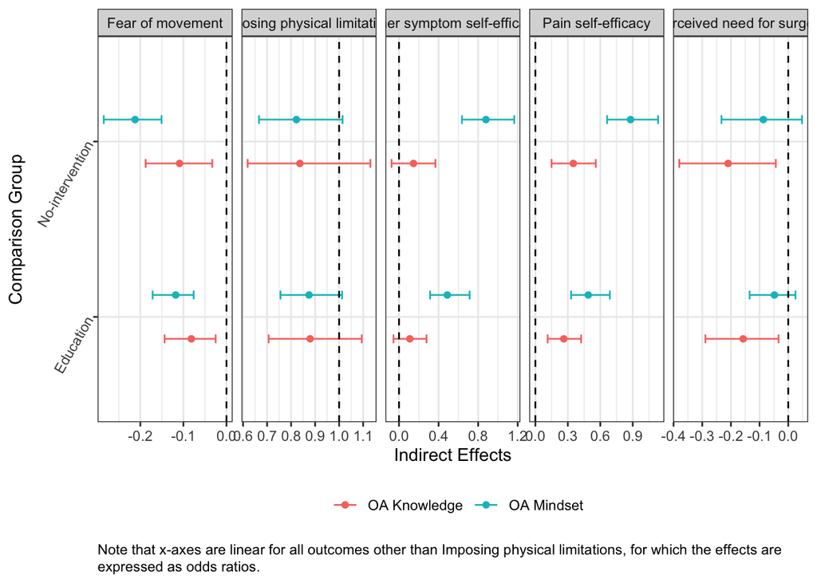

```r
est_df = joint_df %>%
  select(-c(pvalue)) %>%
  mutate(Effect = factor(Effect, levels = c("Total", "OA Knowledge", "OA Mindset"))) %>%
  rename(Est = est, Measure = Effect) %>%
  filter(Measure != "Total")

pd = position_dodge(width = 0.5, orientation = "y")
ref_lines = data.frame(Outcome = out_names,
                       xint = c(0,1,0,0,0))
out_plot = est_df %>%
  mutate(Est = case_when(Outcome == "Imposing physical limitations" ~ exp(Est),
                         TRUE ~ Est),
         CI_UB = case_when(Outcome == "Imposing physical limitations" ~ exp(CI_UB),
                         TRUE ~ CI_UB),
         CI_LB = case_when(Outcome == "Imposing physical limitations" ~ exp(CI_LB),
                         TRUE ~ CI_LB)) %>%
  ggplot(aes(x = Est, y = Comparison, group = Measure, color = Measure)) +
  geom_point(position = pd) +
  geom_errorbar(aes(xmin = CI_LB, xmax = CI_UB), width = 0.1,
                position = pd) +
  geom_vline(data = ref_lines, aes(xintercept = xint), linetype = "dashed") +
  theme_bw() +
  theme(axis.text.y = element_text(angle = 60, vjust = 0.5, hjust = 1),
        plot.caption = element_textbox_simple(margin = margin(t = 10)),
        legend.position = "bottom") +
  facet_wrap(.~Outcome, scales = "free_x", nrow = 1) +
  labs(x = "Indirect Effects", y = "Comparison Group", caption = "Note that x-axes are linear for all outcomes other than Imposing physical limitations, for which the effects are expressed as odds ratios.",
       color = "")
ggsave("Vis.png", out_plot, height = 5, width = 12)
out_plot
```

# Exploratory Latent Factor Models

To understand what might be leading to the impact of both mindset and the education arms on physical activity, we fit mediation models which include latent factors aiming to incorporate mindset variables, fear of movement, and self-efficacy variates collected at the various time points. We begin by examining how many latent factors will be appropriate for this data. We proceed under the assumption that the factor weights will be consistent over time.

```r
factor_vars = c(paste0("t", 1:3, "_KOAS"),
                paste0("t", 1:3, "_OAcomp"),
                paste0("t", 1:3, "_PEM_avg"),
                paste0("t", c(1,3), "_PASE_total"))

# Rescale all variables for numerical stability 0-10 scale
{
  max_KOAS = max(df %>% select(all_of(factor_vars[c(1,2,3)])) %>% as.matrix() %>% c()) / 10
  max_OAC = max(df %>% select(all_of(factor_vars[c(4,5,6)])) %>% as.matrix() %>% c()) / 10
  max_PEM = max(df %>% select(all_of(factor_vars[c(7,8,9)])) %>% as.matrix() %>% c()) / 10
  max_PASE = max(df %>% select(all_of(factor_vars[c(10,11)])) %>% as.matrix() %>% c()) / 10
}

# Data for latent modeling
latent_df = df %>%
  mutate(
    Edu = case_when(group == "Education" ~ 1, TRUE ~ 0),
    No = case_when(group == "No-intervention" ~ 1, TRUE ~ 0),
    across(all_of(factor_vars[c(1,2,3)]), ~ .x/max_KOAS),
    across(all_of(factor_vars[c(4,5,6)]), ~ .x/max_OAC),
    across(all_of(factor_vars[c(7,8,9)]), ~ .x/max_PEM),
    across(all_of(factor_vars[c(10,11)]), ~ .x/max_PASE)) %>%
  select(all_of(c(factor_vars, "Edu", "No", "group")))

# ELFA models
factor_1 = '
  # Latent factor - time 3
  f1_t3 =~ l11 * t3_KOAS + l12 * t3_OAcomp + l13 * t3_PEM_avg

  # Latent factor - time 2
  f1_t2 =~ l11 * t2_KOAS + l12 * t2_OAcomp + l13 * t2_PEM_avg

  # Latent factor - time 1
  f1_t1 =~ l11 * t1_KOAS + l12 * t1_OAcomp + l13 * t1_PEM_avg

  # Correlated residuals (factors do not capture all autocorrelated variability)
  t3_OAcomp ~~ t2_OAcomp + t1_OAcomp; t2_OAcomp ~~ t1_OAcomp
  t3_KOAS ~~ t2_KOAS + t1_KOAS; t2_KOAS ~~ t1_KOAS
  t3_PEM_avg ~~ t2_PEM_avg + t1_PEM_avg; t2_PEM_avg ~~ t1_PEM_avg

  # Latent factor dependence over time, includes treatment effect
  f1_t3 ~ f1_t2; f1_t2 ~ f1_t1 + No + Edu
'

factor_2 = '
  # Latent factor - time 3
  f1_t3 =~ l11 * t3_KOAS + l12 * t3_OAcomp + l13 * t3_PEM_avg
  f2_t3 =~ l21 * t3_KOAS + l22 * t3_OAcomp + l23 * t3_PEM_avg

  # Latent factor - time 2
  f1_t2 =~ l11 * t2_KOAS + l12 * t2_OAcomp + l13 * t2_PEM_avg
  f2_t2 =~ l21 * t2_KOAS + l22 * t2_OAcomp + l23 * t2_PEM_avg

  # Latent factor - time 1
  f1_t1 =~ l11 * t1_KOAS + l12 * t1_OAcomp + l13 * t1_PEM_avg
  f2_t1 =~ l21 * t1_KOAS + l22 * t1_OAcomp + l23 * t1_PEM_avg

  # Correlated residuals (factors do not capture all autocorrelated variability)
  t3_OAcomp ~~ t2_OAcomp + t1_OAcomp; t2_OAcomp ~~ t1_OAcomp
  t3_KOAS ~~ t2_KOAS + t1_KOAS; t2_KOAS ~~ t1_KOAS
  t3_PEM_avg ~~ t2_PEM_avg + t1_PEM_avg; t2_PEM_avg ~~ t1_PEM_avg

  # Latent factor dependence over time, includes treatment effect
  f1_t3 ~ f1_t2; f1_t2 ~ f1_t1 + No + Edu
  f2_t3 ~ f2_t2; f2_t2 ~ f2_t1 + No + Edu
'

# Fit both models
fit_1 = cfa(factor_1, data = latent_df)
fit_2 = cfa(factor_2, data = latent_df)

# Model with a single factor is statistically superior
lavTestLRT(fit_1, fit_2)
```

|  | Df | AIC | BIC | Chisq | Chisq diff | RMSEA | Df diff | Pr(>Chisq) |
| --- | --- | --- | --- | --- | --- | --- | --- | --- |
| fit_2 | 25 | 10884.73 | 11037.16 | 144.5807 | NA | NA | NA | NA |
| fit_1 | 36 | 10862.73 | 10971.03 | 144.5807 | 4e-10 | 0 | 11 | 1 |

```r
# Single factor model provides similar goodness of fit
summary(fit_1, fit.measures = T)
```

```
## lavaan 0.7-2 ended normally after 49 iterations
##
##   Estimator                                         ML
##   Optimization method                           NLMINB
##   Number of model parameters                        31
##   Number of equality constraints                     4
##
##   Number of observations                           408
##
## Model Test User Model:
##
##   Test statistic                               144.581
##   Degrees of freedom                                36
##   P-value (Chi-square)                           0.000
##
## Model Test Baseline Model:
##
##   Test statistic                              2960.838
##   Degrees of freedom                                54
##   P-value                                        0.000
##
## User Model versus Baseline Model:
##
##   Comparative Fit Index (CFI)                    0.963
##   Tucker-Lewis Index (TLI)                       0.944
##
## Loglikelihood and Information Criteria:
##
##   Loglikelihood user model (H0)              -5404.364
##   Loglikelihood unrestricted model (H1)      -5332.073
##
##   Akaike (AIC)                               10862.728
##   Bayesian (BIC)                             10971.032
##   Sample-size adjusted Bayesian (SABIC)      10885.356
##
## Root Mean Square Error of Approximation:
##
##   RMSEA                                          0.086
##   90 Percent confidence interval - lower         0.072
##   90 Percent confidence interval - upper         0.101
```

[output cut: 60 more lines]

```
##
## Variances:
##                    Estimate  Std.Err  z-value  P(>|z|)
##    .t3_KOAS           0.896    0.087   10.262    0.000
##    .t3_OAcomp         1.732    0.249    6.971    0.000
##    .t3_PEM_avg        1.104    0.087   12.704    0.000
##    .t2_KOAS           0.926    0.089   10.459    0.000
##    .t2_OAcomp         1.671    0.242    6.916    0.000
##    .t2_PEM_avg        1.194    0.093   12.885    0.000
##    .t1_KOAS           0.791    0.076   10.371    0.000
##    .t1_OAcomp         2.085    0.241    8.649    0.000
##    .t1_PEM_avg        1.036    0.081   12.847    0.000
##    .f1_t3             0.205    0.029    7.054    0.000
##    .f1_t2             0.177    0.033    5.274    0.000
##     f1_t1             0.524    0.069    7.591    0.000
```

```r
summary(fit_2, fit.measures = T)
```

```
## lavaan 0.7-2 ended normally after 58 iterations
##
##   Estimator                                         ML
##   Optimization method                           NLMINB
##   Number of model parameters                        46
##   Number of equality constraints                     8
##
##   Number of observations                           408
##
## Model Test User Model:
##
##   Test statistic                               144.581
##   Degrees of freedom                                25
##   P-value (Chi-square)                           0.000
##
## Model Test Baseline Model:
##
##   Test statistic                              2960.838
##   Degrees of freedom                                54
##   P-value                                        0.000
##
## User Model versus Baseline Model:
##
##   Comparative Fit Index (CFI)                    0.959
##   Tucker-Lewis Index (TLI)                       0.911
##
## Loglikelihood and Information Criteria:
##
##   Loglikelihood user model (H0)              -5404.364
##   Loglikelihood unrestricted model (H1)      -5332.073
##
##   Akaike (AIC)                               10884.728
##   Bayesian (BIC)                             11037.156
##   Sample-size adjusted Bayesian (SABIC)      10916.576
##
## Root Mean Square Error of Approximation:
##
##   RMSEA                                          0.108
##   90 Percent confidence interval - lower         0.092
##   90 Percent confidence interval - upper         0.126
```

[output cut: 85 more lines]

```
##    .t3_KOAS           0.896    0.087   10.262    0.000
##    .t3_OAcomp         1.732    0.249    6.971    0.000
##    .t3_PEM_avg        1.104    0.087   12.704    0.000
##    .t2_KOAS           0.926    0.089   10.459    0.000
##    .t2_OAcomp         1.671    0.242    6.916    0.000
##    .t2_PEM_avg        1.194    0.093   12.885    0.000
##    .t1_KOAS           0.791    0.076   10.371    0.000
##    .t1_OAcomp         2.085    0.241    8.649    0.000
##    .t1_PEM_avg        1.036    0.081   12.847    0.000
##    .f1_t3             0.068    0.005   13.926    0.000
##    .f2_t3             0.068    0.005   13.926    0.000
##    .f1_t2             0.088    0.017    5.274    0.000
##    .f2_t2             0.088    0.017    5.274    0.000
##     f1_t1             0.121    0.011   10.491    0.000
##     f2_t1             0.121    0.011   10.491    0.000
```

The above analyses indicate a better fit for the model with one factor, as well as an acceptable representation of the data for this model according to standard goodness of fit metrics. As a result, we proceed with using one latent factor.

```r
set.seed(123456)

# Mediation and first factor fit
latent_mod = '
   # Latent factor - time 3
  f1_t3 =~ l11 * t3_KOAS + l12 * t3_OAcomp + l13 * t3_PEM_avg

  # Latent factor - time 2
  f1_t2 =~ l11 * t2_KOAS + l12 * t2_OAcomp + l13 * t2_PEM_avg

  # Latent factor - time 1
  f1_t1 =~ l11 * t1_KOAS + l12 * t1_OAcomp + l13 * t1_PEM_avg

  # Correlated residuals (factors do not capture all autocorrelated variability)
  t3_OAcomp ~~ t2_OAcomp + t1_OAcomp; t2_OAcomp ~~ t1_OAcomp
  t3_KOAS ~~ t2_KOAS + t1_KOAS; t2_KOAS ~~ t1_KOAS
  t3_PEM_avg ~~ t2_PEM_avg + t1_PEM_avg; t2_PEM_avg ~~ t1_PEM_avg

  # Latent factor dependence over time, includes treatment effect
  f1_t3 ~ f1_t2

  # Mediation models, includes treatment effect
  f1_t2 ~ a1 * No + a2 * Edu + f1_t1

  # Outcome model
  t3_PASE_total ~ c1 * No + c2 * Edu + d * f1_t2 + t1_PASE_total

  # Indirect effects
  med_F1_No := a1 * d
  med_F1_Edu := a2 * d

  # Total effects
  total_B_No := c1 + a1 * d
  total_B_Edu := c2 + a2 * d
'

latent_fit = sem(
  model = latent_mod,
  data = latent_df,
  parallel = "multicore",
  ncpus = 8,
  se = "boot",
  bootstrap = 50000
)

# Latent factor mediation
parameterEstimates(latent_fit, boot.ci.type = "bca.simple") %>%
  filter(label %in% c("med_F1_No", "med_F1_Edu",
                      "total_B_No", "total_B_Edu")) %>%
  select(label, est, pvalue, ci.lower, ci.upper) %>%
  separate_wider_delim(label,
                       delim = "_",
                       names = c("Type", "Factor", "Comparison")) %>%
  mutate(Effect = case_when(Type == "med" ~ "Indirect Effect",
                            TRUE ~ "Total Effect"),
         Comparison = case_when(Comparison == "No" ~ "No-intervention",
                                TRUE ~ "Education"),
         est = -1 * est, CI_LB = -1 * ci.upper, CI_UB = -1 * ci.lower) %>%
  select(Comparison, Effect, est, CI_LB, CI_UB, pvalue) %>%
  data.frame() %>%
  rename(Estimate = est, `CI Lower` = CI_LB, `CI Upper` = CI_UB, `P Value` = pvalue)
```

| Comparison | Effect | Estimate | CI Lower | CI Upper | P Value |
| --- | --- | --- | --- | --- | --- |
| No-intervention | Indirect Effect | 0.3394797 | 0.11351276 | 0.6021689 | 0.0060518471 |
| Education | Indirect Effect | 0.2182023 | 0.07244829 | 0.3960087 | 0.0078146699 |
| No-intervention | Total Effect | 0.5052951 | 0.20545513 | 0.8052016 | 0.0009959142 |
| Education | Total Effect | 0.1042771 | -0.19100211 | 0.4000832 | 0.4909604318 |

```r
{
  weights = parameterEstimates(latent_fit, boot.ci.type = "norm") %>%
    filter(label %in% c("l11", "l12", "l13")) %>%
     select(label, est) %>%
    group_by(label) %>%
    summarise(est = first(est)) %>%
    arrange(label) %>%
    pull(est)

  names(weights) = c("OA Knowledge", "OA Mindset", "Exercise Mindset")
  print(weights)
}
```

```
##     OA Knowledge       OA Mindset Exercise Mindset
##        1.0000000        1.9085622        0.7411624
```

We see that the latent factor weights OA knowledge and exercise mindset similarly positive, with OA mindset having a much greater positive weight.

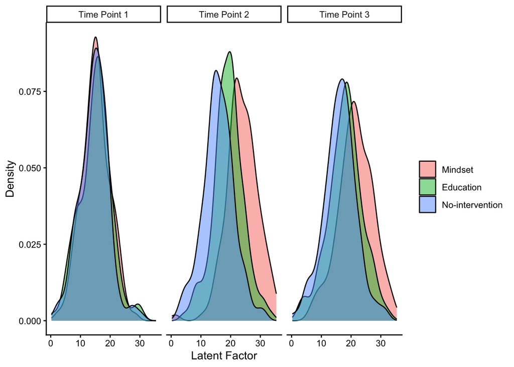

```r
latent_plot_df = latent_df %>%
  mutate(latent_1 = weights[1] * t1_KOAS +
           weights[2] * t1_OAcomp +
           weights[3] * t1_PEM_avg,
         latent_2 = weights[1] * t2_KOAS +
           weights[2] * t2_OAcomp +
           weights[3] * t2_PEM_avg,
         latent_3 = weights[1] * t3_KOAS +
           weights[2] * t3_OAcomp +
           weights[3] * t3_PEM_avg) %>%
  select(group, latent_1, latent_2, latent_3) %>%
  mutate(ID = row_number()) %>%
  pivot_longer(-c(ID, group), names_to = "Time", values_to = "Latent") %>%
  mutate(Time = case_when(Time == "latent_1" ~ "Time Point 1",
                          Time == "latent_2" ~ "Time Point 2",
                          TRUE ~"Time Point 3"),
         group = factor(group, levels = c("Mindset", "Education", "No-intervention")))

# Densities at each time point
latent_plot_df %>%
  ggplot(aes(x = Latent, group = group, fill = group)) +
  geom_density(alpha = 0.5) +
  theme_classic() +
  facet_grid(.~Time) +
  labs(fill = "", x = "Latent Factor", y = "Density")
```

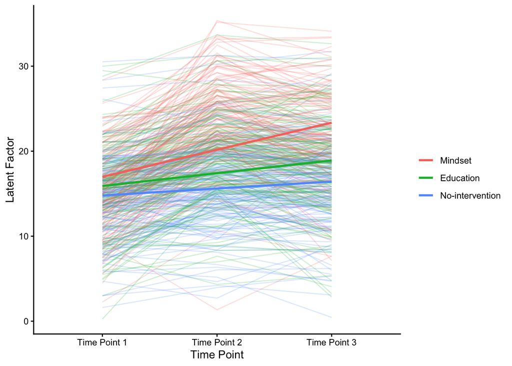

```r
# Trajectories by group over time
latent_plot_df %>%
  ggplot(aes(x = Time, y = Latent)) +
  geom_line(aes(group = ID, color = group), alpha = 0.2) +
  geom_smooth(aes(group = group, color = group), method = "lm",
              se = F) +
  theme_classic() +
  labs(x = "Time Point", y = "Latent Factor", color = "")
```